# Project : Coursera - Practical Machine Learning

Christian Spakowski

20 August 2017

## Introduction

Using devices such as Jawbone Up, Nike FuelBand, and Fitbit it is now possible to collect a large amount of data about personal activity relatively inexpensively. These type of devices are part of the quantified self movement – a group of enthusiasts who take measurements about themselves regularly to improve their health, to find patterns in their behavior, or because they are tech geeks. One thing that people regularly do is quantify how much of a particular activity they do, but they rarely quantify how well they do it. In this project, your goal will be to use data from accelerometers on the belt, forearm, arm, and dumbell of 6 participants. They were asked to perform barbell lifts correctly and incorrectly in 5 different ways.

## Data

The training data for this project are available here:

https://d396qusza40orc.cloudfront.net/predmachlearn/pml-training.csv

The test data are available here:

https://d396qusza40orc.cloudfront.net/predmachlearn/pml-testing.csv

The data for this project come from this source: http://web.archive.org/web/20161224072740/http:/groupware.les.inf.puc-rio.br/har. If you use the document you create for this class for any purpose please cite them as they have been very generous in allowing their data to be used for this kind of assignment.

## Loading Libraries and the Data

```r
# Loading libraries
library(caret)
library(randomForest)
library(ggplot2)
library(ggthemes)
library(dplyr)


# Load Data
training <- read.csv("pml-training.csv", na.strings = c("NA", "#DIV/0!", ""))
validating <- read.csv("pml-testing.csv",na.strings=c("NA","#DIV/0!"))
```

## Data Cleaning

Inspecting the data shows, that many columns contain many NA values. First we write a function to remove these columns from the data. Moreover we will remove columns that will not be helpful for model training like Username etc. Finally we will transform the prediction column to categorical data.

```r
# Write Function to remove NA Cols
remove_NAcols <- function(data) {
  # Find Cols with NA vlaues
  NAcols_count <- sapply(1:dim(data)[2],function(x) sum(is.na(data[,x])))
  NAcols <- which(NAcols_count > 0)

  return(data[,-NAcols])
}

# Remove NA columns
training <- remove_NAcols(training)
validating <- remove_NAcols(validating)

# Remove uninteresting Columns like user name etc.
training <- training[,-c(1:7)]
validating <- validating[,-c(1:7)]

# Transform classe Col to factor
training$classe <- factor(training$classe)
```

## Model Training

We will use a Random Forest Classifier to fit the data. First we will split the Training data so that we can later quantify the performance of our model. Then we will fit our data via RandomForest Classification and then evaluate the performance.

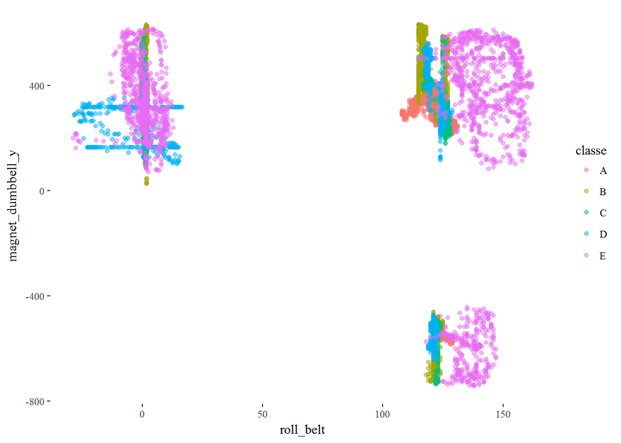

```r
# Set seed and split training data into training and test data
set.seed(1986)
inTrain <- createDataPartition(y=training$classe, p=0.6, list=FALSE)
training <-training[inTrain,]
testing <- training[-inTrain,]

# Training model with RandomForest
model <- randomForest(classe~., data=training, method='class')
# Predict data
pred <- predict(model,testing,type='class')

# Plot Data
training %>%
  ggplot(aes(x = roll_belt, y = magnet_dumbbell_y, col = classe)) +
  geom_point(alpha = 0.5) +
  theme_tufte()
```

```r
confusionMatrix(pred, testing$classe)[2]
```

```
## $table
##           Reference
## Prediction    A    B    C    D    E
##          A 1366    0    0    0    0
##          B    0  883    0    0    0
##          C    0    0  792    0    0
##          D    0    0    0  810    0
##          E    0    0    0    0  879
```

## Using our model

Finally we use our model to predict data, that our model has not seen yet.

```r
pred_test <-  predict(model, validating, type='class')
pred_test
```

```
##  1  2  3  4  5  6  7  8  9 10 11 12 13 14 15 16 17 18 19 20
##  B  A  B  A  A  E  D  B  A  A  B  C  B  A  E  E  A  B  B  B
## Levels: A B C D E
```